# Rating VQ and Nasalisation Pharyngeals

##### 3.2.4.1.2 Figures

###### 3.2.4.1.2.1 Subjects

```r
ciVQSubj <- subRanefVQSubj + qnorm(0.975) * sqrt(as.numeric(subcondVarVQSubj)) %o% c(-1, 1)
ord.reVQSubj <- order(subRanefVQSubj)
ciVQSubj <- ciVQSubj[order(subRanefVQSubj),]
plot(subRanefVQSubj[ord.reVQSubj], 1:9, axes=FALSE, xlim=range(ciVQSubj),
     xlab="Subject variation", ylab="",cex=2,cex.lab=2,cex.main=2,
     main="BLUPs Subject VQ",cex.axis=1.5)
axis(1,cex.lab=2,cex.axis=1.5)
```

```r
axis(2,at=1:9, labels = levels(ord.reLabelVQSubj$x), las=2,cex.lab=2,cex.axis=1.5)
for(i in 1:9) segments(ciVQSubj[i,1], i, ciVQSubj[i, 2],i)
```

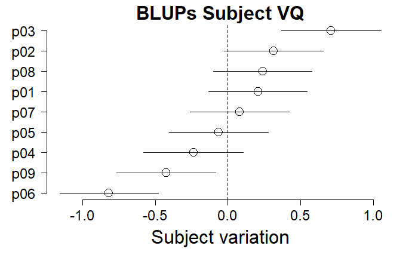

```r
abline(v = 0, lty=2)
```

It is interesting to see that not all subjects (who produced the items) were rated as more or less “tense”. The first two subjects (2 and 3) contributed more to the percept of “tense” voice quality whereas speakers 6, 9 and 4, contributed less to this percept.

###### 3.2.4.1.2.2 Raters

```r
ciVQRater <- subRanefVQRater + qnorm(0.975) * sqrt(as.numeric(subcondVarVQRater)) %o% c(-1, 1)
ord.reVQRater <- order(subRanefVQRater)
ciVQRater <- ciVQRater[order(subRanefVQRater),]
plot(subRanefVQRater[ord.reVQRater], 1:6, axes=FALSE, xlim=range(ciVQRater),
     xlab="Rater variation", ylab="",cex=2,cex.lab=2,cex.main=2,
     main="BLUPs Rater VQ",cex.axis=1.5)
axis(1,cex.lab=2,cex.axis=1.5)
```

```r
axis(2,at=1:6, labels = levels(ord.reLabelVQRater$x), las=2,cex.lab=2,cex.axis=1.5)
for(i in 1:6) segments(ciVQRater[i,1], i, ciVQRater[i, 2],i)
```

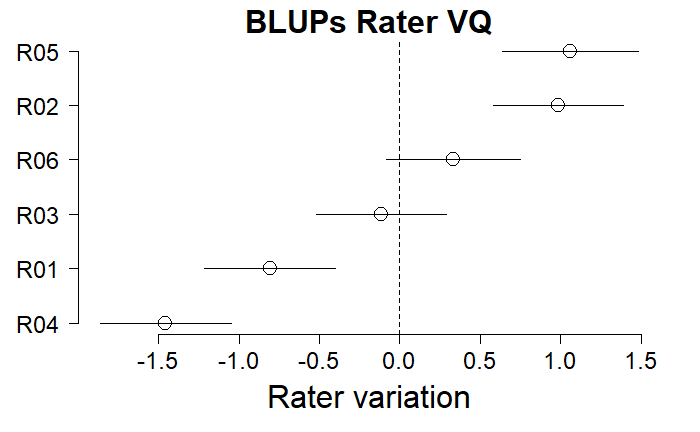

```r
abline(v = 0, lty=2)
```

With respect to raters, it is interesting to see that there is a clear split between raters (that was already picked up in the IRR analyses above). The first three (2, 5 and 6) were more likely to provide postive responses to “tense” whereas 1 and 4 (and potentially 3) were more conservative in their responses. R01 is the first author and R02 is the second. This shows that R01 is more conservative in their responses than R02.

###### 3.2.4.1.2.3 Items

```r
ciVQWord <- subRanefVQWord + qnorm(0.975) * sqrt(as.numeric(subcondVarVQWord)) %o% c(-1, 1)
ord.reVQWord <- order(subRanefVQWord)
ciVQWord <- ciVQWord[order(subRanefVQWord),]
par(oma = c(0, 1.5, 0, 0))
plot(1:45,subRanefVQWord[ord.reVQWord], axes=FALSE, ylim=range(ciVQWord),
       ylab="Item variation", xlab="",cex=2,cex.lab=2,cex.main=2,
     main="BLUPs Item VQ",cex.axis=1.5)
axis(2,cex.lab=2,cex.axis=1.5)
```

```r
axis(1,at=1:45, labels = levels(ord.reLabelVQWord$x), las=2,cex.lab=2,cex.axis=1.5)
for(i in 1:45) segments(i, ciVQWord[i,1], i, ciVQWord[i, 2])
```

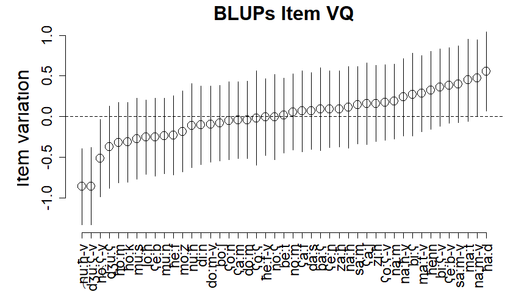

```r
abline(h = 0, lty=2)
```

With item variation, not all words contributed positively to the “tense” quality and there is a clear gradation in impact of words on ratings. This is important to take into account of course in our model